# Bio 724: More ggplot2

Author

Paul Magwene

# Libraries

```r
library(tidyverse)
library(RColorBrewer)

# ggplot2 extensions
library(ggrepel)
library(GGally)
library(ggmagnify)

# data
library(palmerpenguins)
```

## Depicting 3D data using color

- ggplot2 has no built-in support for 3D graphs; instead it emphasizes the use of color, or other aesthetics, to depict more than two dimensions
- Contour plots and heat maps are among the most common ways to generate figures representing 3D data in ggplot

### Contour plots

Contour plots are most useful when you want to represent a variable (say “z”) as a function of two other variables (x and y). Contour plots use nested lines (think contour lines on a topographic map) and optionally color to depict such relationships.

Take for example the mathematical function: $z = \sin(x) + \cos(y)$. A 3D plot of this function looks like this (generated using Wolfram Alpha):

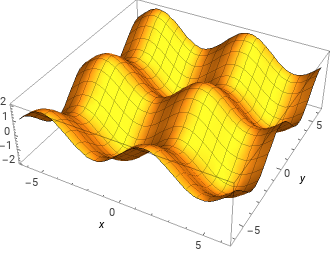

3d plot

Below is code to generate the representation of a contour plot for the same function:

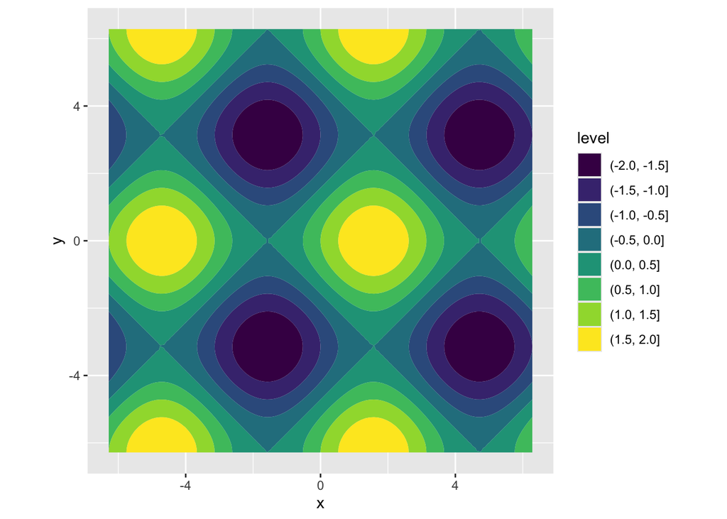

```r
zfunc <- function(x,y) {
  sin(x) + cos(y)
}
# try some other functions!
# e.g. z = sin(sqrt(x^2 + y^2))


# create sets of points over which to evaluate zfunc
x <- seq(-2*pi, 2*pi, length = 100)
y <- seq(-2*pi, 2*pi, length = 100)

# expand grid creates all pairwise combinations of x and y
xy <- expand_grid(x,y)

xyz <- mutate(xy, z = zfunc(x,y))

ggplot(xyz, aes(x = x, y = y, z = z)) +
  geom_contour_filled() +   # try with geom_contour() instead
  coord_equal()
```

I think a diverging color scheme makes more sense here, since the data is centered around zero. I like the “RdBu” (red-blue) diverging color scheme for data like this, but reversed (so blue = low, red = high)

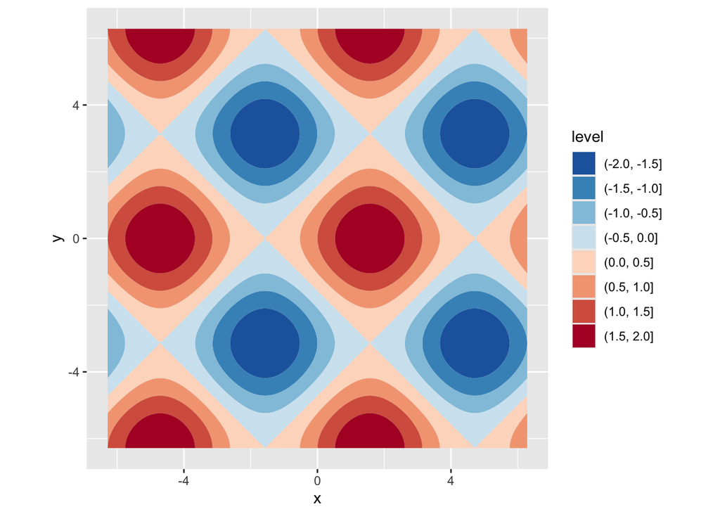

```r
blue.red.color.scheme <- rev(brewer.pal(9,"RdBu"))

ggplot(xyz, aes(x = x, y = y, z = z)) +
  geom_contour_filled() +
  # direction = -1 reverse the color scheme direction
  scale_fill_brewer(palette = "RdBu", direction = -1) +
  coord_equal()
```

### Heat maps

Heat maps are another way to depict 3D data with color. Typically the x, y axes represent a combination of a categorical variable and a continuous variable.

`geom_tile` (for small data) and `geom_raster` (for large data) are the standard ggplot2 functions for creating heat maps.

Here we create a heat map showing gene expression over time for about 700 genes that were identified as showing cell cycle oscillatory behavior by Spellman et al. 1998:

First load and filter the data:

```r
yeast_long <- read_csv("spellman-long.csv")
cell_cycle <- read_csv("spellman-cell-cycle-list.txt")

# get just the cell cycle genes as given in the cdc28 exptl conditions
cdc28_cell_cycle <-
  yeast_long |>
  filter(gene %in% cell_cycle$Gene) |>
  filter(expt == "cdc28")

# Q: how would you do the first filter step with a join?
# Q: could you combine the two filters above?
```

Then draw the plot:

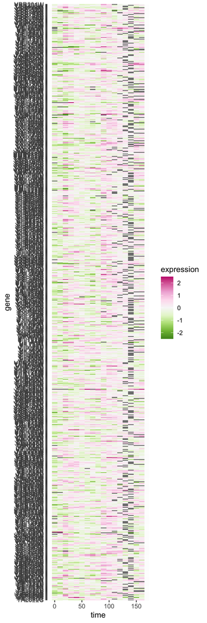

```r
# let's explicitly generate a color scheme
color.scheme <- rev(brewer.pal(9,"PiYG"))

cdc28_cell_cycle |>
  ggplot(aes(x = time, y = gene, fill = expression)) +
  geom_raster(aes(fill = expression)) +  #
  scale_fill_gradientn(limits=c(-2.5, 2.5), colors=color.scheme)
```

The real power of heat maps becomes apparent when you you rearrange the rows of the heat map to emphasize patterns of interest. For example, let’s recreate that heat map in which we sort genes by the time of their maximal expression. This is one way to identify genes that reach their peak expression at similar times, which is one criteria one might use to identify genes acting in concert.

```r
peak.expression <-
  cdc28_cell_cycle |>
  group_by(gene) |>
  summarize(peak = which.max(expression)) |>
  arrange(peak)
```

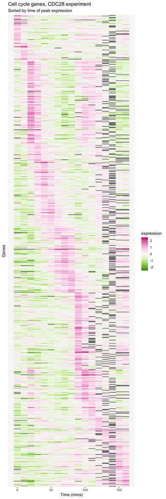

```r
# draw from the bottom row up, whereas we want to depict the
# earliest peaking genes at the top of the figure
gene.ordering <- rev(peak.expression$gene)


better_heat <-
  cdc28_cell_cycle |>
  ggplot(aes(x = time, y = gene, fill = expression)) +
  geom_raster(aes(fill = expression)) +  #
  scale_fill_gradientn(limits=c(-2.5, 2.5), colors=color.scheme) +
  scale_y_discrete(limits=gene.ordering) +
  labs(x = "Time (mins)",
       y = "Genes",
       title = "Cell cycle genes, CDC28 experiment",
       subtitle = "Sorted by time of peak expression") +
  theme(axis.text.y = element_blank(), axis.ticks.y = element_blank())

better_heat
```

```r
ggsave("cdc28-heatmap.png", better_heat,  width = 4, height = 12, dpi=600)
```

## ggplot2 extensions

There is an “official” gallery for ggplot2 extensions, which can be found at the following URL: https://exts.ggplot2.tidyverse.org/index.html

We’ve already used some ggplot2 extensions, such as `patchwork`. Today we’ll introduce a few more

- ggrepel – for annotation / labeling; https://ggrepel.slowkow.com/
- ggmagnify – magnified insets; https://github.com/hughjonesd/ggmagnify – see also https://ggforce.data-imaginist.com/ for a facet style “zoom”

## Basic annotations

### Highlighting via layers

A simple way to highlight data of interest is by layering geoms.

Here for example we highlight two points in a data set by stacking two `geom_point` layers:

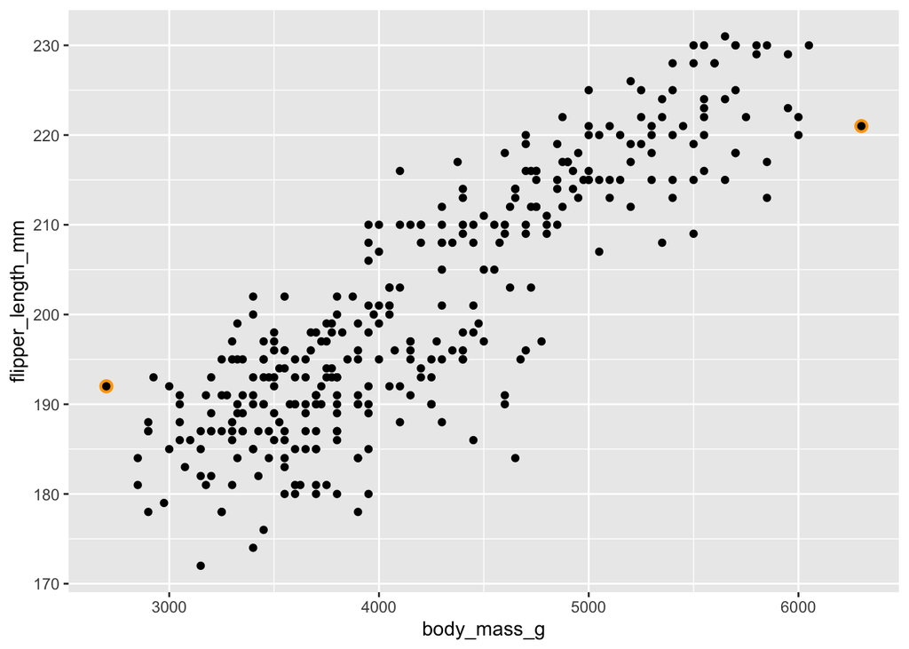

```r
# highlight biggest and smallest penguins by body mass
penguins |>
  ggplot(aes(x = body_mass_g, y = flipper_length_mm)) +
  geom_point(
    data = filter(penguins |> drop_na(body_mass_g),
                  body_mass_g >= max(body_mass_g) | body_mass_g <= min(body_mass_g)),
    color = "orange",
    size = 3) +
  geom_point()
```

### Annotating

ggplot has an `annotate` function for drawing text, line segments, curves, etc to explicitly call out features in plots.

From the `annotate` help: “This function adds geoms to a plot, but unlike a typical geom function, the properties of the geoms are not mapped from variables of a data frame, but are instead passed in as vectors”

Here’s an updated version of the figure above to which we’ve added text and arrows:

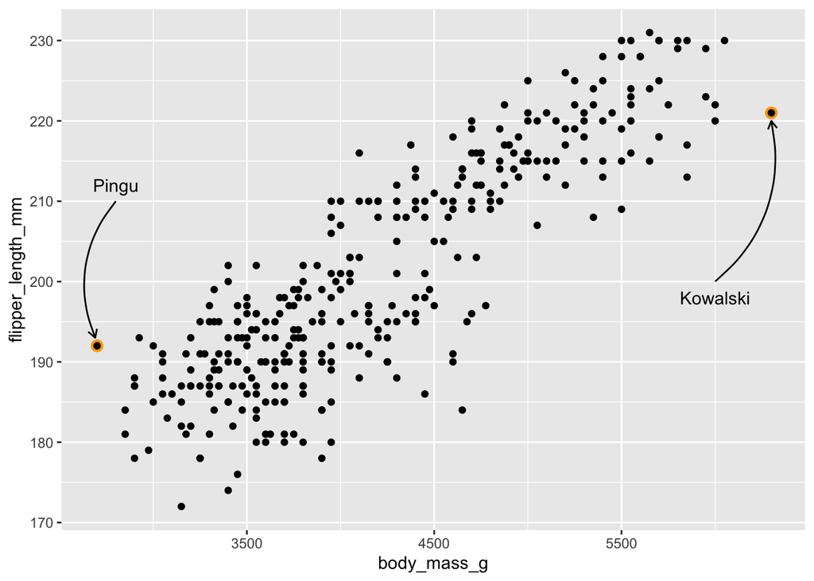

```r
penguins |>
  ggplot(aes(x = body_mass_g, y = flipper_length_mm)) +
  geom_point(
    data = filter(penguins |> drop_na(body_mass_g),
                  body_mass_g >= max(body_mass_g) | body_mass_g <= min(body_mass_g)),
    color = "orange",
    size = 3) +
  geom_point() +
  annotate(geom = "curve",
           x = 6000, y = 200, xend = 6300, yend = 220,
           curvature = .3, arrow = arrow(length = unit(2, "mm"))) +
  annotate(geom = "text",
           x = 6000, y = 198,
           label = "Kowalski", hjust = "center") +
  annotate(geom = "curve",
           x = 2800, y = 210, xend = 2690, yend = 193,
          curvature = .3, arrow = arrow(length = unit(2, "mm"))) +
  annotate(geom = "text",
           x = 2800, y = 212,
           label = "Pingu", hjust = "center")
```

### Magnifying regions of a plot

ggmagnify provides a geom for “zooming in” on a region of a plot.

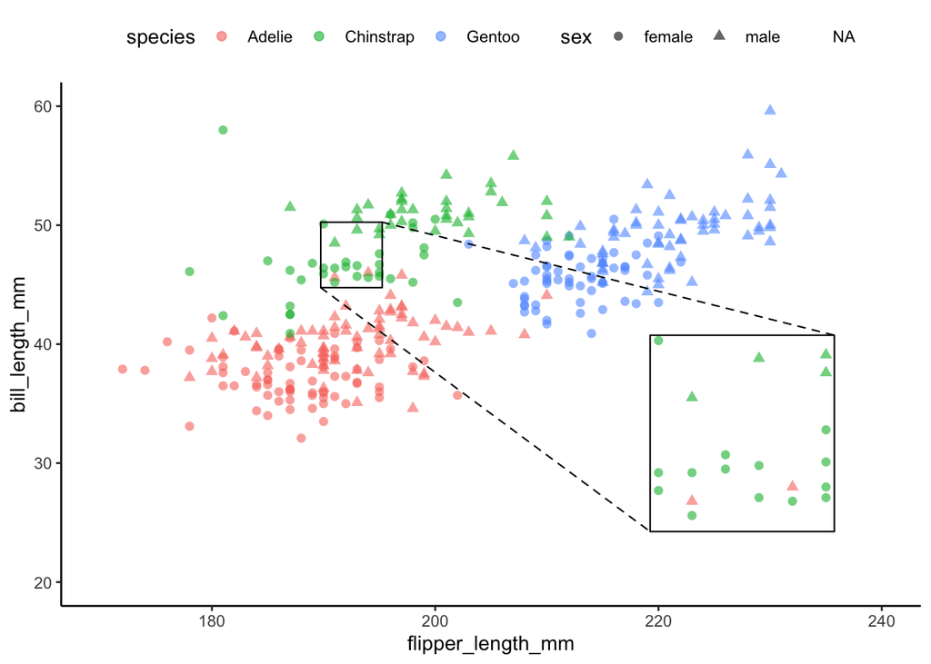

```r
z <- ggplot(penguins,
       aes(x = flipper_length_mm,
           y = bill_length_mm,
           color = species,
           shape = sex)) +
  geom_point(size=2, alpha=0.6) +
  theme_classic() +
  geom_magnify(from = c(190,195,45,50), to = c(220, 235, 25,40)) +
  coord_cartesian(xlim = c(170,240), ylim = c(20,60)) +
  theme(legend.position = "top")

z
```

### Labeling points

Labeling points with text is another form of annotation. The function `geom_text` supports basically labeling, but as we’ll see below it has some limitations. A ggplot extension package called `ggrepel` extends the functionality of `geom_text`, allowing for nicer automatic labelling of points.

#### Example data: Microbescope

The website [Information is Beautiful](https://informationisbeautiful.net/) has lots of interesting data visualizations and “data stories”. One of the data stories of biomedical interest is the [MicrobeScope](https://informationisbeautiful.net/visualizations/the-microbescope-infectious-diseases-in-context/), which presents data on the contagiousness of various microbes and its relationship to deadliness, fatality rate, media coverage, etc.

[figure not shown]

Microscope figures

I’ve made a cleaned up version of the data used to produce the figure above available to you as a CSV file at the following URL:

- microbescope_clean.csv – this data was derived from the “original data” sheet in the data provided at http://bit.ly/KIB_Microbescope

```r
microbescope <- read_csv("microbescope_clean.csv")
```

#### Basic `geom_text` plot

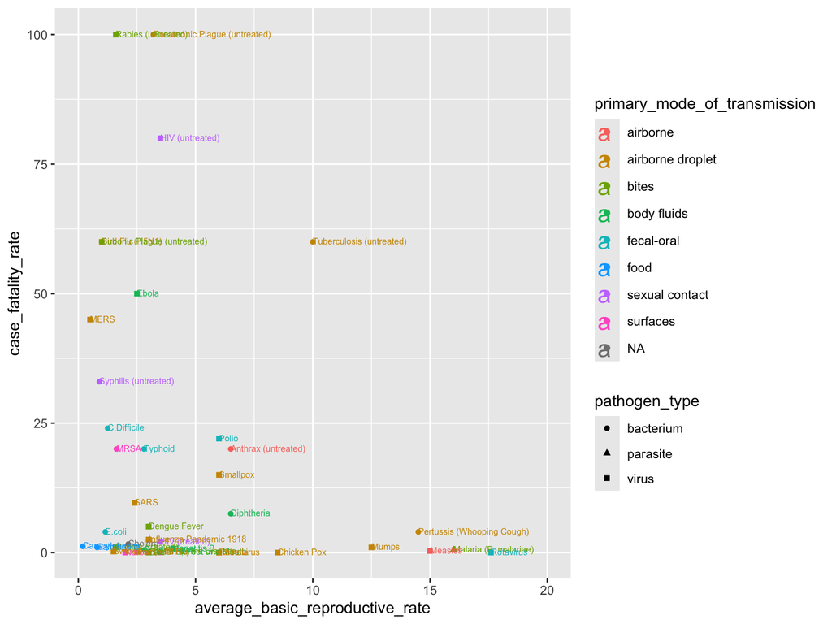

```r
ggplot(microbescope) +
  aes(x = average_basic_reproductive_rate,
      y = case_fatality_rate,
      shape = pathogen_type,
      color = primary_mode_of_transmission) +
  geom_point() +
  geom_text(aes(label=disease),
            size = 6,
            size.unit = "pt",
            hjust=0, nudge_y = 0.15,
            ) +
  coord_cartesian(xlim = c(0,20))
```

#### Extended version using ggrepel

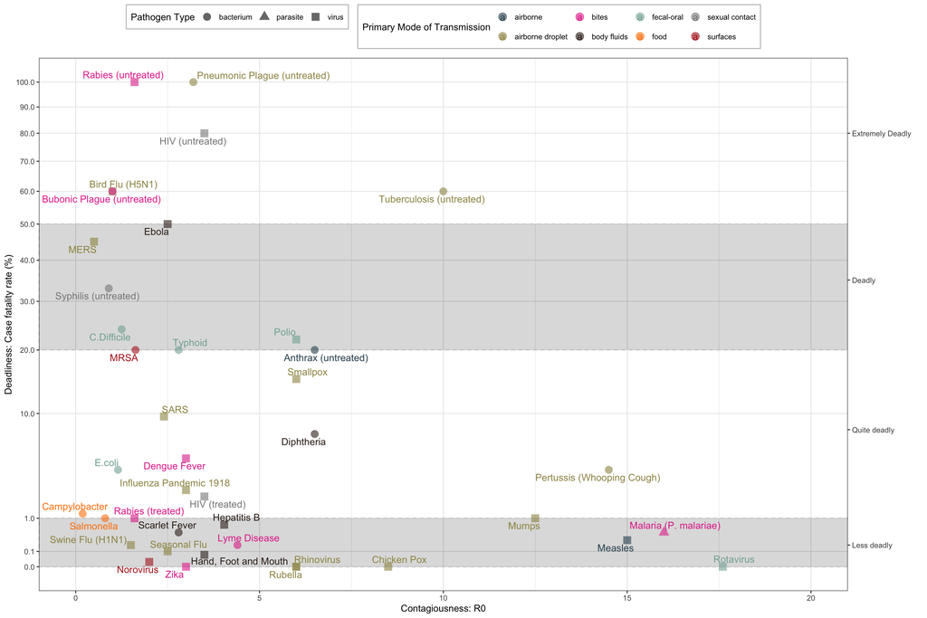

```r
my_colors <- c("#335060","#9d9353","#e13698","#37251e",
               "#81aea3","#ff8106","#888888", "firebrick")

microbescope |>
  drop_na() |>
  filter(average_basic_reproductive_rate < 20) |>
  ggplot(aes(x = average_basic_reproductive_rate,
             y = case_fatality_rate,
             shape = pathogen_type,
             color = primary_mode_of_transmission)) +
  # draw background rectangles
  geom_rect(aes(ymin=0, ymax=1,xmin=-1,xmax=21),
            alpha=0.003,color='#D3D3D3', linetype="dashed") +
  geom_rect(aes(ymin=20, ymax=50,xmin=-1,xmax=21),
            alpha=0.003,color='#D3D3D3', linetype="dashed") +
  # draw points
  geom_point(size=4, alpha=0.6) +
  scale_color_manual(values = my_colors) +
  # draw labels
  geom_text_repel(aes(label=disease),
                  size = 4,
                  force = 1,
                  force_pull = 2) +
  scale_y_sqrt(breaks=c(0,0.1,1,seq(10,100,10)),
               minor_breaks = NULL,
               sec.axis = dup_axis(name = "",
                                   breaks = c(0.2, 8, 35, 80),
                                   labels = c("Less deadly", "Quite deadly", "Deadly", "Extremely Deadly"))) +

  coord_cartesian(xlim = c(0,20)) +
  labs(x = "Contagiousness: R0",
       y = "Deadliness: Case fatality rate (%)") +

  theme_bw() +
  theme(legend.position = "top", legend.background = element_rect(size = 0.5, colour='grey')) +
  guides(color = guide_legend(title = "Primary Mode of Transmission"),
         shape = guide_legend(title = "Pathogen Type"))
```

```r
ggsave("microbescope.png", width = 14, height=8)
```

## Misc

- GGally – ggpairs; https://ggobi.github.io/ggally/articles/ggpairs.html

The `ggpairs` function from the package GGally is really useful for exploratory data analysis. It will generate a “matrix” of plots representing the relationships between all pairs of variables in a data frame. It handles continuous and categorical data well:

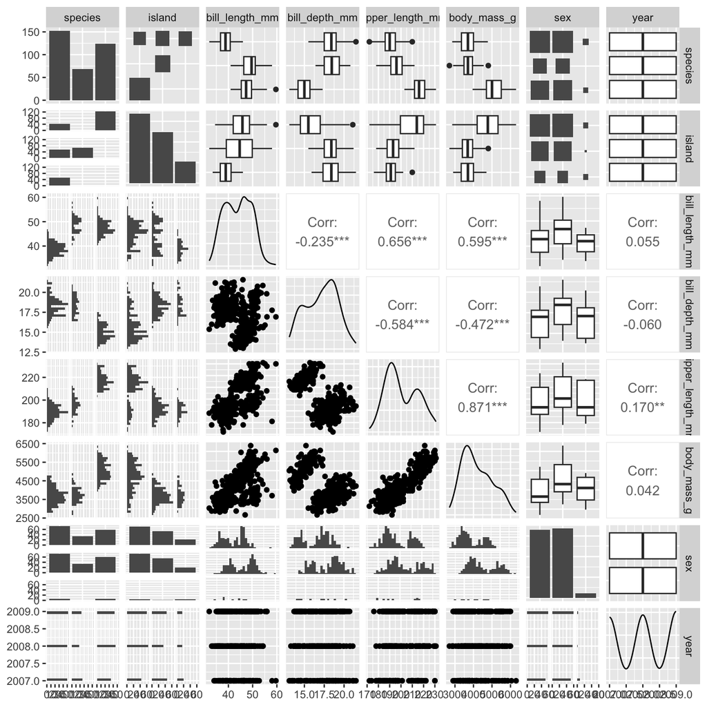

```r
ggpairs(penguins)
```